# Milestoneproject

Luis Fernando Perez Armas

January 3, 2019

# Milestone Report

The first step in building a predictive model for text is understanding the distribution and relationship between the words, tokens, and phrases in the text. The goal of this task is to understand the basic relationships you observe in the data and prepare to build your first linguistic models.

Tasks to accomplish:

Exploratory analysis:

- perform a thorough exploratory analysis of the data, understanding the distribution of words and relationship between the words in the corpora.
- Understand frequencies of words and word pairs - build figures and tables to understand variation in the frequencies of words and word pairs in the data.

## R setup

```r
setwd("~/Data Science/Jhon Hopkins/Capstone/Week2")
library(ggplot2)
library(quanteda)
library(data.table)
library(dplyr)
```

## File basic information

The following app and report will be built using only english textdata therefore we will select data from twitter blogs and news only in english lenguage

### File size

```r
list.files()
```

```
## [1] "en_US.blogs.txt"   "en_US.news.txt"    "en_US.twitter.txt"
## [4] "Milestone.html"    "Milestone.Rmd"     "Milestone_cache"
## [7] "Milestone_files"   "muestra.txt"       "W2milestone.R"
```

```r
file.info("en_US.blogs.txt")$size/1024^2
```

```
## [1] 200.4242
```

```r
file.info("en_US.news.txt")$size/1024^2
```

```
## [1] 196.2775
```

```r
file.info("en_US.twitter.txt")$size/1024^2
```

```
## [1] 159.3641
```

The average file size is in the order of 200Mb which is certainly not a trivial size

### Read and upload the data

```r
blogs<-readLines("en_US.blogs.txt",skipNul = TRUE, warn = TRUE)
news<-readLines("en_US.news.txt",skipNul = TRUE, warn = TRUE)
twitter<-readLines("en_US.twitter.txt",skipNul = TRUE,warn = TRUE)
```

### Number of lines

```r
length(blogs)
```

```
## [1] 899288
```

```r
length(news)
```

```
## [1] 77259
```

```r
length(twitter)
```

```
## [1] 2360148
```

### Max number of characters per line

```r
max(nchar(blogs))
```

```
## [1] 40835
```

```r
max(nchar(news))
```

```
## [1] 5760
```

```r
max(nchar(twitter))
```

```
## [1] 213
```

### Mean number of characters per line

```r
mean(nchar(blogs))
```

```
## [1] 231.696
```

```r
mean(nchar(news))
```

```
## [1] 203.0024
```

```r
mean(nchar(twitter))
```

```
## [1] 68.8029
```

### Summary of nchar

```r
summary(nchar(blogs))
```

```
##    Min. 1st Qu.  Median    Mean 3rd Qu.    Max.
##     1.0    47.0   157.0   231.7   331.0 40835.0
```

```r
summary(nchar(news))
```

```
##    Min. 1st Qu.  Median    Mean 3rd Qu.    Max.
##       2     111     186     203     270    5760
```

```r
summary(nchar(twitter))
```

```
##    Min. 1st Qu.  Median    Mean 3rd Qu.    Max.
##     2.0    37.0    64.0    68.8   100.0   213.0
```

## Data sample unification

The data is to massive to process it completely specially if we consider constrains related to mobile cellphone memory therefore just a sample will be used for the models generation

```r
set.seed(3007)
sam_blogs<-sample(blogs,size = 3000,replace = TRUE)
sam_news<-sample(news,size = 3000,replace = TRUE)
sam_twitter<-sample(twitter,size = 3000,replace = TRUE)
muestra<-c(sam_blogs,sam_news,sam_twitter)

writeLines(muestra,"muestra.txt")

rm(blogs,twitter,news)
rm(sam_blogs,sam_news,sam_twitter)

muestra<-as.data.frame(muestra)
names(muestra)<-c("text")
muestra$text<-as.character(muestra$text)
nrow(muestra)
```

```
## [1] 9000
```

It is important to verify if there are missing values on the data set, specially after unification

```r
length(which(!complete.cases(muestra)))
```

```
## [1] 0
```

We can confirm that the sample has no missing values and therefore we are good to proceed forward

## Unigram Creation

For most of the cleaning and tokenization process we are going to use the quanteda package functions

```r
train.tokens<-tokens(muestra$text,what="word",remove_numbers = TRUE, remove_punct = TRUE,
                     remove_symbols = TRUE, remove_separators = TRUE,
                     remove_twitter = TRUE, remove_hyphens = TRUE, remove_url = TRUE)

train.tokens<-tokens_tolower(train.tokens)

train.tokens.dfm <- dfm(train.tokens,tolower = FALSE)
```

text data is already tokenized what we need to do next is to calculate the frequency of each of the token words

```r
unigram_freq<-colSums(train.tokens.dfm)
termFreq <- data.frame(unigram=names(unigram_freq), frequency=unigram_freq)

termFreq <-arrange(termFreq,desc(termFreq$frequency))
top10<-head(termFreq,10)
top10
```

```
##    unigram frequency
## 1      the     13267
## 2       to      7255
## 3      and      6659
## 4        a      6256
## 5       of      5774
## 6       in      4565
## 7        i      3876
## 8     that      2803
## 9       is      2787
## 10     for      2760
```

Plotting the unigram

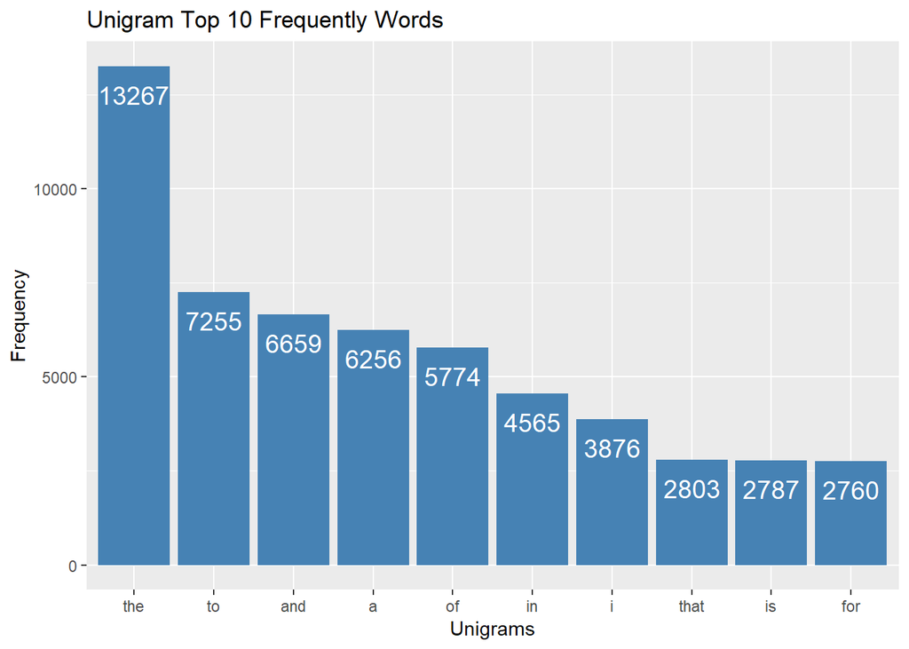

```r
g1<-ggplot(data = top10,aes(x=reorder(unigram,-frequency),y=top10$frequency))
g1<-g1 + geom_bar(stat = "identity",fill = "steelblue")+geom_text(data = top10,aes(x=top10$unigram,y=top10$frequency,label = top10$frequency),hjust=0.5,vjust=2, position = "identity",size = 5,color = "White")
g1<-g1 + ggtitle("Unigram Top 10 Frequently Words") + xlab("Unigrams") + ylab("Frequency")
g1
```

## Bigram Creation

To create n>1 grams we will use the quanteda function tokens_ngrams

```r
bigram.token <-tokens_ngrams(train.tokens,n=2)
bigram.token.dfm <- dfm(bigram.token,tolower = FALSE)

bigram_freq<-colSums(bigram.token.dfm)
bigram_termfreq<-data.frame(bigram=names(bigram_freq),frequency=bigram_freq)

bigram_termfreq<-arrange(bigram_termfreq,desc(bigram_termfreq$frequency))
top10bigram<-head(bigram_termfreq,10)
top10bigram
```

```
##      bigram frequency
## 1    of_the      1259
## 2    in_the      1172
## 3    to_the       599
## 4    on_the       513
## 5   for_the       496
## 6     to_be       423
## 7    at_the       374
## 8      in_a       362
## 9   and_the       354
## 10 with_the       320
```

Plotting the bigram

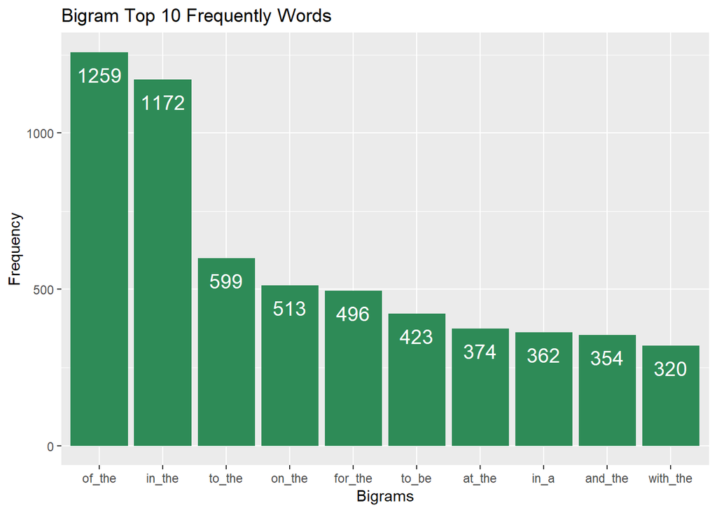

```r
g2<-ggplot(data = top10bigram,aes(x=reorder(bigram,-frequency),y=top10bigram$frequency))
g2<-g2 + geom_bar(stat = "identity",fill = "seagreen4")+geom_text(data = top10bigram,aes(x=top10bigram$bigram,y=top10bigram$frequency,label = top10bigram$frequency),hjust=0.5,vjust=2, position = "identity",size = 5,color = "White")
g2<-g2 + ggtitle("Bigram Top 10 Frequently Words") + xlab("Bigrams") + ylab("Frequency")
g2
```

## Trigram Creation

```r
trigram.token <-tokens_ngrams(train.tokens,n=3)
trigram.token.dfm<-dfm(trigram.token,tolower = FALSE)

trigram_freq<-colSums(trigram.token.dfm)
trigram_termfreq<-data.frame(trigram=names(trigram_freq),frequency=trigram_freq)

trigram_termfreq<-arrange(trigram_termfreq,desc(trigram_termfreq$frequency))
top10trigram<-head(trigram_termfreq,10)
```

Plotting trigrams

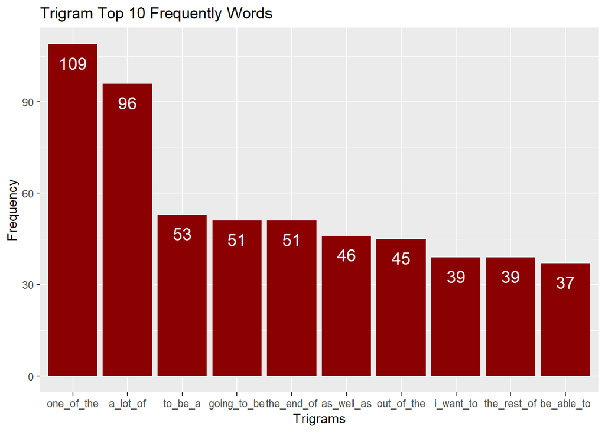

```r
g3<-ggplot(data = top10trigram,aes(x=reorder(trigram,-frequency),y=top10trigram$frequency))
g3<-g3 + geom_bar(stat = "identity",fill = "red4")+geom_text(data = top10trigram,aes(x=top10trigram$trigram,y=top10trigram$frequency,label = top10trigram$frequency),hjust=0.5,vjust=2, position = "identity",size = 5,color = "White")
g3<-g3 + ggtitle("Trigram Top 10 Frequently Words") + xlab("Trigrams") + ylab("Frequency")
g3
```

## Quadgrams creation

```r
quadgram.token <-tokens_ngrams(train.tokens,n=4)
quadgram.token.dfm<-dfm(quadgram.token,tolower=FALSE)

quadgram_freq<-colSums(quadgram.token.dfm)
quadgram_termfreq<-data.frame(quadgram=names(quadgram_freq),frequency=quadgram_freq)
quadgram_termfreq<-arrange(quadgram_termfreq,desc(quadgram_termfreq$frequency))

top10quadgram<-head(quadgram_termfreq,10)
```

Plotting Quadgrams

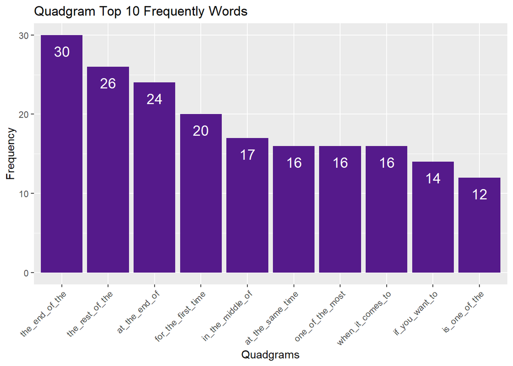

```r
g4<-ggplot(data = top10quadgram,aes(x=reorder(quadgram,-frequency),y=top10quadgram$frequency))
g4<-g4 + geom_bar(stat = "identity",fill = "purple4")+geom_text(data = top10quadgram,aes(x=top10quadgram$quadgram,y=top10quadgram$frequency,label = top10quadgram$frequency),hjust=0.5,vjust=2, position = "identity",size = 5,color = "White")
g4<-g4 + ggtitle("Quadgram Top 10 Frequently Words") + xlab("Quadgrams") + ylab("Frequency")
g4<-g4 + theme(axis.text.x=element_text(angle=45,hjust=1))
g4
```

## Pentagrams creation

```r
pentagram.token <-tokens_ngrams(train.tokens,n=5)
pentagram.token.dfm<-dfm(pentagram.token,tolower = FALSE)

pentagram_freq<-colSums(pentagram.token.dfm)
pentagram_termfreq<-data.frame(pentagram=names(pentagram_freq),frequency=pentagram_freq)
pentagram_termfreq<-arrange(pentagram_termfreq,desc(pentagram_termfreq$frequency))

top10pentagram<-head(pentagram_termfreq,10)
top10pentagram
```

```
##                      pentagram frequency
## 1            at_the_end_of_the        12
## 2         in_the_middle_of_the         9
## 3        for_the_first_time_in         7
## 4    obama_bin_laden_obama_bin         7
## 5    bin_laden_obama_bin_laden         7
## 6            by_the_end_of_the         6
## 7  laden_obama_bin_laden_obama         6
## 8           the_end_of_the_day         5
## 9          i_want_to_bring_the         4
## 10      want_to_bring_the_best         4
```

Plotting pentagrams

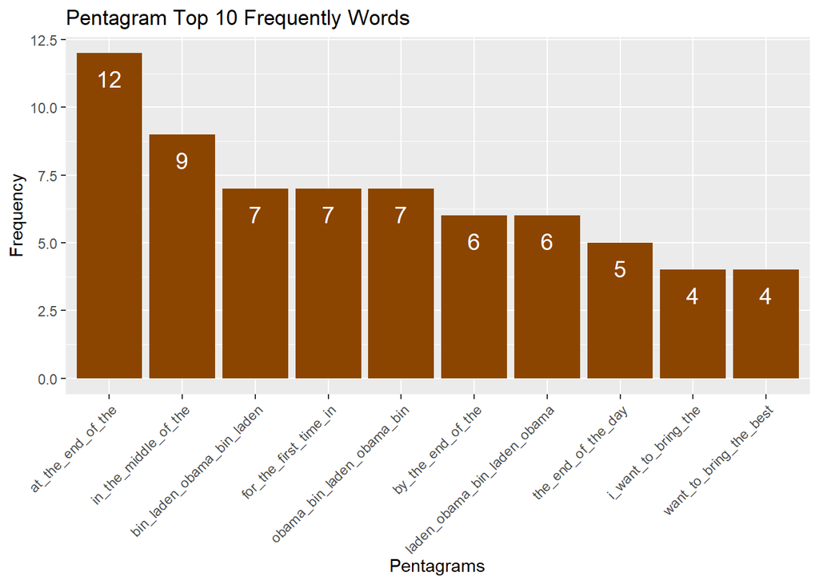

```r
g5<-ggplot(data = top10pentagram,aes(x=reorder(pentagram,-frequency),y=top10pentagram$frequency))
g5<-g5 + geom_bar(stat = "identity",fill = "darkorange4")+geom_text(data = top10pentagram,aes(x=top10pentagram$pentagram,y=top10pentagram$frequency,label = top10pentagram$frequency),hjust=0.5,vjust=2, position = "identity",size = 5,color = "White")
g5<-g5 + ggtitle("Pentagram Top 10 Frequently Words") + xlab("Pentagrams") + ylab("Frequency")
g5<-g5 + theme(axis.text.x=element_text(angle=45,hjust=1))
g5
```